# Advanced Bioinformatics Assignment 2022

m2108729

2022-04-28

## Task 3.1

The sum of all integers between 5 and 55 using the sum() function

```r
sum(5:55)
```

```
## [1] 1530
```

## Task 3.2

Creating a function “sumfun” with only one input “n” which calculates the sum of all integers between 5 and n.

```r
sumfun <- function(sumvalue) {
  sum(5:sumvalue)
}
```

Using the sumfun function to do the calculation for n = 10, n = 20, n = 100 and present the results by first creating a vector of the n values, then applying the lapply function to all values within the the sumfunresult vector and printing the result.

```r
sumfunresult <- c(10, 20, 100)
lapply(sumfunresult, FUN = sumfun) # using the lapply function to apply sumfun to all variables in the sumfunresult vector
```

```
## [[1]]
## [1] 45
##
## [[2]]
## [1] 200
##
## [[3]]
## [1] 5040
```

## Task 3.3

Fibonacci series using a loop to print out the first 12 entries and print the first 12 fibonacci

```r
fibonacci = function(n) { # create a function fibonacci to calculate fibonacci on n values
x = numeric(n) # values of numeric type
x[1:2] = 1 # sets the first two values as 1
for(i in 3:n) x[i] = x[i-1] + x[i-2] # repeats the loop from the third value
return(x) # return the new vector
}

fibonacci(12)
```

```
##  [1]   1   1   2   3   5   8  13  21  34  55  89 144
```

## Task 3.4

Use ggplot to generate a box of miles per gallon as a function of the number of gears using the fill aesthetic to colour the bars on the number of gears. Titles are also added and centrally aligned for the plot, each axis and the key.

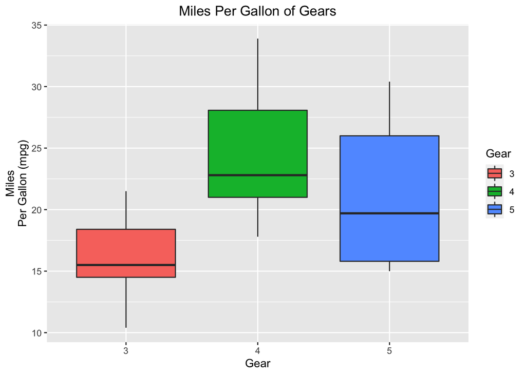

```r
data(mtcars)
library(ggplot2)

mtcars$gear <- as.factor(mtcars$gear) # sets the gear variable as a factor rather than a numeric
p <- ggplot(mtcars, aes(x=gear, y=mpg, fill=gear)) +
  geom_boxplot()+ xlab("Gear") + ylab("Miles
Per Gallon (mpg)") + scale_fill_discrete(name = "Gear") +
  ggtitle("Miles Per Gallon of Gears")
p + theme(plot.title= element_text(hjust = 0.5))
```

## Task 3.5 Using the lm function to fit a linear relationship between speed and braking distance. What are the fitted slope and intercept of the line, and their standard errors? What are the units used for the variables in the dataset?

```r
data(cars) # load cars data into Rstudio
summary.cars <- lm(cars, formula = dist ~ speed)  # apply the linear model to the x and y variables
summary(summary.cars) # display summary statistics of the linear model
```

```
##
## Call:
## lm(formula = dist ~ speed, data = cars)
##
## Residuals:
##     Min      1Q  Median      3Q     Max
## -29.069  -9.525  -2.272   9.215  43.201
##
## Coefficients:
##             Estimate Std. Error t value Pr(>|t|)
## (Intercept) -17.5791     6.7584  -2.601   0.0123 *
## speed         3.9324     0.4155   9.464 1.49e-12 ***
## ---
## Signif. codes:  0 '***' 0.001 '**' 0.01 '*' 0.05 '.' 0.1 ' ' 1
##
## Residual standard error: 15.38 on 48 degrees of freedom
## Multiple R-squared:  0.6511, Adjusted R-squared:  0.6438
## F-statistic: 89.57 on 1 and 48 DF,  p-value: 1.49e-12
```

```r
help(cars) #provides information on the units used
```

Answers: The fitted slope: 3.9324 The intercept: -17.5791 The standard errors: 0.4155 (fitted slope) and 6.7584 (intercept) Units used: speed (miles per hour) and distance (feet)

## Task 3.6

Using ggplot to plot the data points from Task 3.5 and the linear fit.

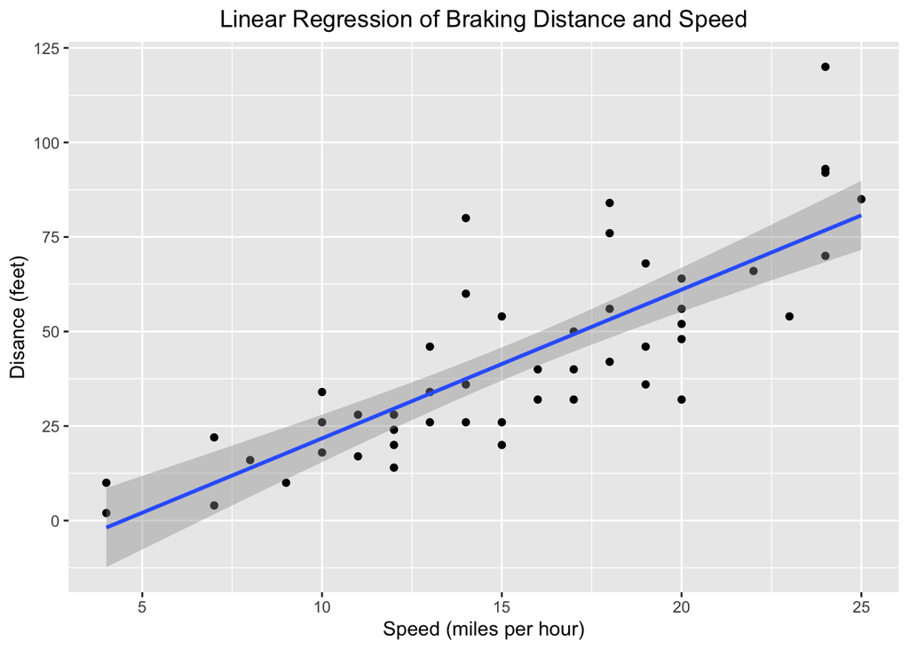

```r
carsplot <- ggplot(cars, aes(x=speed, y=dist)) +
  geom_point() + geom_smooth(formula= y ~ x, method=lm) + # create a scatterplot
  xlab("Speed (miles per hour)") + ylab("Disance (feet)") + # add axis labels
  ggtitle("Linear Regression of Braking Distance and Speed") # add a title

carsplot + theme(plot.title= element_text(hjust = 0.5)) # reposition the title to the centre
```

## Task 3.7

Using linear regression (lm) to estimate the average reaction time for the driver to start breaking (in seconds).

```r
# create a variable dist.miles which is the braking distance in miles instead of feet
dist.miles <- cars$dist* 0.000189394 # convert the braking distance in feet into miles
# create a variable called speed.lin
braking.dist <- cars$speed^2 # if breaking distance is proportional to the square of the speed then square the speed
# using lm to apply the linear model to the two variables
lm(formula = dist.miles ~ braking.dist)
```

```
##
## Call:
## lm(formula = dist.miles ~ braking.dist)
##
## Coefficients:
##  (Intercept)  braking.dist
##    1.678e-03     2.443e-05
```

```r
# the slope must be equal to the average reaction time
reaction.time <- 2.443e-05 # this is the average reaction time in hours
# convert the average reaction time into seconds (1 hour = 3600 seconds)
reaction.time.seconds <- reaction.time*3600
reaction.time.seconds
```

```
## [1] 0.087948
```

The average braking reaction time to respond to a stimulus is 0.2 seconds, which means this value is very fast. However, the average braking reaction time can be based upon a number of variables such as driver characteristics (driver temperament, level of fatigue and experience), the environmental conditions (weather, road quality) and the colour and size of the hazard. Given that the data is taken from the 1920’s the different braking system could be responsible for this faster value. Therefore, it seems reasonable.

Use ggplot to plot the data points and the fitted relationship.

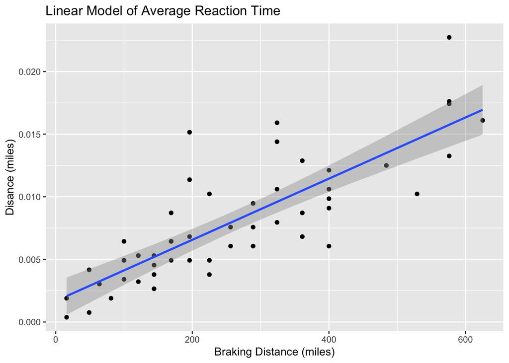

```r
plot5 <- data.frame(dist.miles, braking.dist)
linear.plot <- ggplot(plot5, aes(x=braking.dist, y=dist.miles)) +
                        geom_point() + geom_smooth(method = "lm", formula = y ~ x) +
  xlab("Braking Distance (miles)") + ylab("Disance (miles)") + # add axis labels
  ggtitle("Linear Model of Average Reaction Time") # add a title
linear.plot
```